# Statistical Power Calculation

### **NOTES ON STATISTICS, PROBABILITY and MATHEMATICS**

### Power Calculation:

See also [this post](https://rinterested.github.io/statistics/sample_size.html).

*Motivating scenario: Meta-alpha protein (MAP) levels of 25 mg/mL are considered top normal in the population at large ($\mu_o$). However, we are studying a group of 20 ($n=20$) subjects with a severe deficit in glycophospholids (GLy) with MAP concentrations of 28 mg/mL with a standard deviation of 5 mg/mL. The question is what is the power of a $t$ test to reject the $H_o$ hypothesis when it is false, and conclude that people with deficit in GLy have higher levels of MAP?*

These plots show the dependence of power on the true mean of the alternative hypothesis: the closer it is to the mean of $H_o$ the less power to reject $H_o$ when it is false. At its limit, when both means coincide, the power becomes identical to the $\alpha$ risk.

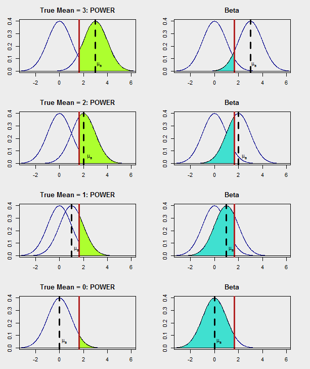

These plots show the dependence of power on the true mean of the alternative hypothesis: the closer it is to the mean of $H_o$ the less power to reject $H_o$ when it is false. At its limit, when both means coincide, the power becomes identical to the $alpha$ risk.

The probability of a type II error is $\beta$. In other words, it is the probability of *not* rejecting $H_o$ when it is false.

Therefore, probability of rejecting $H_o$ when it is false will be $1 - \beta$. And this is exactly the definition of *POWER*:

### $POWER \, = \, 1\,-\,\beta$

Power is exactly the probability that the test statistic lies in the rejection region *under* the premise that $H_a$ is correct.

For a single-group mean test we are comparing a normalized mean to a $t$ quantile to test if the group mean belongs to a different population, i.e. $H_a: \mu_a>\mu_o$.

$\Pr\left(\Large\frac{\bar X - \mu_o}{s/\sqrt{n}}\,> t_{1-\alpha,\,n-1}\mid \mu=\mu_a\right)$

However, if $n$ is large we can do instead normal calculations:

$\Pr\left(\Large\frac{\bar X - \mu_o}{s/\sqrt{n}}\,> z_{1-\alpha}\mid\mu=\mu_a\right)\small \tag 1$

That is to say, we want to calculate the probability that our test statistic will reject the null *under* or given that the alternative is true.

$$\begin{align}
\Pr\left(\Large\frac{\bar X - \mu_a \, + \mu_a -\mu_o}{s/\sqrt{n}}\,>
z_{1-\alpha}\mid \mu=\mu_a\right)\\[2ex]
=\Pr\left(\Large\frac{\bar X - \mu_a}{\sigma/\sqrt{n}} >
\,z_{1-\alpha}\, -\frac{\mu_a -\mu_o}{s/\sqrt{n}}\mid
\mu=\mu_a\right)\small \tag 2\\[2ex]
=\Pr\left(Z> \, z_{1-\alpha} -\frac{\mu_a -\mu_o}{s/\sqrt{n}}\mid
\mu=\mu_a\right)
\end{align}$$

Here’re two examples from a Coursera course:

1. Researchers would like to conduct a study of $100$ healthy adults to detect a four year mean brain volume loss of $0.01 \,\text{mm}^3$. Assume that the standard deviation of four year volume loss in this population is $0.04 \,\text{mm}^3$. What would be the power of the study for a 5% one sided test versus a null hypothesis of no volume loss?

The hypothesis is $H_o: \mu_{\Delta}=0$ v. $H_a: \mu_{\Delta}>0$ where $\mu_{\Delta}$ is the volume loss. The test statistics is $\large \frac{\bar X_{\Delta}}{\frac{sd}{\sqrt{n}}}=10\frac{\bar X_{\Delta}}{0.04}$ which is rejected if it is larger than $Z_{0.95}=1.645$.

We want to calculate:

$\Pr\left(\frac{\bar X_\Delta}{\sigma_\Delta / 10} > 1.645 \mid \mu_\Delta = .01\right) \,\text{[eq.1 above]} = \Pr\left( \frac{\bar X_\Delta - .01}{.004} > 1. 645 - \frac{.01}{.004} \mid \mu_\Delta = .01\right)\,\text{[eq.2 above]} = \Pr(Z > −.855) = .80$

```r
pnorm(-0.855, lower.tail = FALSE)
```

```
## [1] 0.8037244
```

```r
pnorm(1.645 * 0.004, mean = 0.01, sd = 0.004, lower.tail = FALSE)
```

```
## [1] 0.8037244
```

2. Researchers would like to conduct a study of $n$ healthy adults to detect a four year mean brain volume loss of $0.01\,\text{mm}^3$. Assume that the standard deviation of four year volume loss in this population is $0.04\, \text{mm}^3$.

What would be the value of $n$ needed for $90\%$ power of type one error rate of $5\%$ one sided test versus a null hypothesis of no volume loss?

The hypothesis is $H_o: \mu_{\Delta}=0$ v. $H_a: \mu_{\Delta}>0$ where $\mu_{\Delta}$ is the volume loss. The test statistics is $\frac{\bar X_{\Delta}}{0.04/\sqrt{n}}$ which is rejected if it is larger than $Z_{0.95}=1.645$.

We want to calculate:

$\Pr\left(\frac{\bar X_\Delta}{\sigma_\Delta / \sqrt{n}} > 1.645 \mid \mu_\Delta = .01\right) = \Pr\left( \frac{\bar X_\Delta - .01}{.04 / \sqrt{n}} > 1. 645 - \frac{.01}{.04 / \sqrt{n}} \mid \mu_\Delta = .01\right) = \Pr(Z > 1.645 - \sqrt{n} / 4) = .90$

So we need $1.645 - \sqrt{n} / 4 = Z_{.10} = \text{qnorm}(.1) = -1.282$ and thus $n = ( 4 \times (1.645 + 1.282) )^ 2=137.0773.$

```r
ceiling((4 * (qnorm(0.95) - qnorm(0.1)))^2) # The negative sign is because qnorm(0.1) is negative.
```

```
## [1] 138
```

But we started off saying that we were comparing to a $t$ quantile, so how do we calculate power for a $t$ test:

$$\begin{align}
\Pr\,\left(\frac{\bar X - \mu_o}{s/\sqrt{n}}\,> t_{(1-\alpha,
n-1)}\,\mid \mu=\mu_a\right)\\[2ex]
=\Pr\,\left(\sqrt{n} (\bar X - \mu_o)\,> t_{(1-\alpha, n-1)}\,
s\,\mid \mu=\mu_a\right)\\[2ex]
=\Pr\,\left(\frac{\sqrt{n}\,(\bar X - \mu_o)}{\sigma}\,>
t_{(1-\alpha, n-1)}\,\frac{s}{\sigma}\,\mid \mu=\mu_a\right)\\[2ex]
=\Pr\,\left( \frac{\sqrt{n}\,(\bar X - \mu_a)}{\sigma} +
\frac{\sqrt{n}\,(\mu_a - \mu_o)}{\sigma}\,> \frac{t_{(1-\alpha,
n-1)}}{\sqrt{n-1}}\,\sqrt{\frac{(n-1)\,s^2}{\sigma^2}}\,\,\mid
\mu=\mu_a\right)\\[2ex]
=\Pr\,\left( \frac{\sqrt{n}\,(\bar X - \mu_a)}{\sigma} +
\frac{\sqrt{n}\,(\mu_a - \mu_o)}{\sigma}\,> \frac{t_{(1-\alpha,
n-1)}}{\sqrt{n-1}}\,\sqrt{\chi^2_{n-1}}\,\,\mid\mu=\mu_a\right)\\[2ex]
\Pr\,\left( Z + \frac{\sqrt{n}\,(\mu_a - \mu_o)}{\sigma}\,>
\frac{t_{(1-\alpha,
n-1)}}{\sqrt{n-1}}\,\sqrt{\chi^2_{n-1}}\,\,\mid\mu=\mu_a\right)
\end{align}$$

Note that $\frac{(\mu_a - \mu_o)}{\sigma}$ is the *effect size*. We don’t really have to know $\mu_a$: the effect size (or standardized effect size) is all we need.

For the introduction of the $\Large \chi^2$ refer to:

[Proof of Chi Square distribution of ratio of $\sim s^2/\sigma^2$](https://math.stackexchange.com/questions/1386238/proof-that-frac-displaystyle-sum-x-1n-x-barx2-sigma2-sim). And remember:

$s^2=\frac{\sum(X-\bar{X})^2}{n-1}$.

Since the last equations involve more complex (bivariate) calculations, the power calculation can be achieved via Monte Carlo simulation:

```r
simuls <- 1e5         # Number of simulations
n <- 20               # Sample size
sigma <- 5            # Standard deviation
mu_0 <- 25            # The mean we assume under Ho
mu_a <- 28            # The mean under Ha
Z  <- rnorm(simuls)   # Part of the inequality above
chisqr <- rchisq(simuls, df = n - 1)
t <- qt(.95, n - 1)
# The power is:
mean(Z + sqrt(n) * (mu_a - mu_0) / sigma > t / sqrt(n - 1) * sqrt(chisqr))
```

```
## [1] 0.8278
```

Compare to built-in formulas (equivalent to `sample.prop.test` for proportions):

```r
power.t.test(n = 20, delta = mu_a - mu_0, sd = sigma, type = "one.sample", alt = "one.sided")
```

```
##
##      One-sample t test power calculation
##
##               n = 20
##           delta = 3
##              sd = 5
##       sig.level = 0.05
##           power = 0.8266395
##     alternative = one.sided
```

RELATIONSHIPS:

1. Power goes up as $\alpha$ is larger.
2. Power of a one-sided test is greater than the power of the associated two-sided test - just think of it in terms of smaller $\alpha$ cuts ($\alpha/2$)
3. Power goes up the further $\mu_a$ gets away from $\mu_o$.
4. Power goes up as $n$ goes up.

[Home Page](http://rinterested.github.io/statistics/index.html)

**NOTE: These are tentative notes on different topics for personal use - expect mistakes and misunderstandings.**